# Assignment 2

Author

Kyle Wakerley

# Assignment 2

```r
library(dplyr)
library(ggplot2)
library(tidyr)
#Reading in Data
chs_i = read.csv("C:/Users/kylew/Downloads/chs_individual.csv")
chs_r = read.csv("C:/Users/kylew/Downloads/chs_regional.csv")
```

## Question 1: Merge

```r
chs = merge(chs_i, chs_r, by = intersect(names(chs_i), names(chs_r)))
dim(chs)
```

```
[1] 1200   49
```

After merging, we still have the same number of rows.

### Imputation

```r
#install.packages("DescTools")
library(DescTools)
library(dplyr)

# Change Binary Variables to Categorical

chs = chs %>% mutate(
  asthma = as.character(asthma),
  father_asthma = as.character(father_asthma),
  mother_asthma = as.character(mother_asthma),
  wheeze = as.character(wheeze),
  hayfever = as.character(hayfever),
  allergy = as.character(allergy),
  educ_parent = as.character(educ_parent),
  smoke = as.character(smoke),
  pets = as.character(pets),
  gasstove = as.character(gasstove)
)

#Changing Mode Function to deal with NA values

safe_mode = function(x) {
  m <- Mode(x, na.rm = TRUE)
  if (length(m) == 0) return(NA_character_)
  as.character(m[1])
}

#4 Combinations of Male/Hispanic

mh = chs %>% filter(male == 1 & hispanic == 1)
fh = chs %>% filter(male == 0 & hispanic == 1)
mn = chs %>% filter(male == 1 & hispanic == 0)
fn = chs %>% filter(male == 0 & hispanic == 0)

# For Males who are Hispanic

mh_imputed = mh %>%
  mutate(
    across(where(is.numeric), ~ ifelse(is.na(.), mean(., na.rm = TRUE), .)),
         across(where(is.character), ~ replace(., is.na(.), safe_mode(.))))

# For females who are Hispanic

fh_imputed = fh %>%
  mutate(
    across(where(is.numeric), ~ ifelse(is.na(.), mean(., na.rm = TRUE), .)),
         across(where(is.character), ~ replace(., is.na(.), safe_mode(.))))

# For males who are not Hispanic

mn_imputed = mn %>%
  mutate(
    across(where(is.numeric), ~ ifelse(is.na(.), mean(., na.rm = TRUE), .)),
         across(where(is.character), ~ replace(., is.na(.), safe_mode(.))))

#For females who are not Hispanic

fn_imputed = fn %>%
  mutate(
    across(where(is.numeric), ~ ifelse(is.na(.), mean(., na.rm = TRUE), .)),
         across(where(is.character), ~ replace(., is.na(.), safe_mode(.))))

chs_imputed = rbind(mh_imputed, fh_imputed, mn_imputed, fn_imputed)

head(chs_imputed) #Snapshot of the Data
```

```
  townname sid male race hispanic    agepft height weight      bmi asthma
1   Alpine 841    1    W        1 10.548939    150     78 15.75758      0
2   Alpine 842    1    M        1  9.489391    139     65 15.29189      0
3   Alpine 844    1    W        1 10.513347    143     65 14.44836      0
4   Alpine 855    1    W        1 10.428474    143     64 14.22608      0
5   Alpine 887    1    O        1 10.529774    138     74 17.66245      1
6   Alpine 900    1    W        1  9.793292    130     52 13.98601      0
  active_asthma father_asthma mother_asthma wheeze hayfever allergy educ_parent
1             0             0             0      0        0       0           5
2             0             0             0      1        0       0           1
3             0             0             0      0        0       0           3
4             0             0             0      0        0       0           1
5             1             0             0      1        0       1           3
6             0             1             0      0        0       0           3
  smoke pets gasstove      fev      fvc     mmef pm25_mass pm25_so4 pm25_no3
```

[output cut: 27 more lines]

To impute the data, I split the data into 4 groups by the binary variables “male” and “Hispanic”. I then replaced NA values in numerical columns to the group mean and the NA values in categorical columns to the group mode. I then combined these 4 subsets to combine the results.

## Question 2: Obesity Level

```r
chs_imputed = chs_imputed %>%
  mutate(obesity_level = case_when(
    bmi < 14 ~ "underweight",
    bmi >= 14 & bmi < 22 ~ "normal",
    bmi >= 22 & bmi <= 24 ~ "overweight",
    bmi > 24 ~ "obese"
  ))

chs_imputed$obesity_level = factor(chs_imputed$obesity_level,
                                   levels = c("underweight",
                                              "normal",
                                              "overweight",
                                              "obese"))

chs_imputed %>%
  group_by(obesity_level) %>%
  summarize(number = n(), min_bmi = min(bmi), max_bmi = max(bmi))
```

```
# A tibble: 4 × 4
  obesity_level number min_bmi max_bmi
  <fct>          <int>   <dbl>   <dbl>
1 underweight       35    11.3    14.0
2 normal           975    14.0    22.0
3 overweight        87    22.0    24.0
4 obese            103    24.0    41.3
```

```r
chs_imputed %>% filter(bmi < 12.5)
```

```
      townname  sid male race hispanic    agepft height weight      bmi asthma
1   Long Beach 1408    0    O        1  9.754962    126     43 12.31132      0
2    San Dimas  199    0    W        1  9.908282    130     42 11.29640      0
3 Lake Gregory 1278    1    W        0 10.058864    127     43 12.11821      0
  active_asthma father_asthma mother_asthma wheeze hayfever allergy educ_parent
1             0             0             0      0        0       0           3
2             0             1             0      0        1       0           3
3             0             0             0      1        0       0           5
  smoke pets gasstove      fev      fvc     mmef pm25_mass pm25_so4 pm25_no3
1     0    1        1 1168.792 1444.631 1355.034     19.12     3.23     6.22
2     0    1        1 1748.773 1993.109 2422.667     20.52     2.59     7.20
3     0    1        1 2090.258 2430.969 2355.892      7.66     1.07     2.07
  pm25_nh4 pm25_oc pm25_ec pm25_om pm10_oc pm10_ec pm10_tc formic acetic  hcl
1     2.57    5.21    1.36    6.25    6.68    1.39    8.07   1.57   2.94 0.73
2     2.71    5.59    1.17    6.71    7.17    1.19    8.37   2.77   4.24 0.55
3     0.91    2.46    0.40    2.96    3.16    0.41    3.57   0.66   2.36 0.28
  hno3 o3_max o3106 o3_24   no2  pm10  no_24hr pm2_5_fr iacid oacid total_acids
1 2.67  39.44 28.22 18.22 33.11 38.41 36.76000    22.23  3.40  4.51        7.18
2 4.07  64.26 46.99 21.63 35.47 38.61 42.95000    25.33  4.62  7.01       11.08
3 2.28  84.44 67.01 57.76  7.62 20.05 16.86197     9.01  2.56  3.02        5.30
        lon      lat obesity_level
1 -118.1937 33.77005   underweight
2 -117.8067 34.10668   underweight
3 -117.2752 34.24290   underweight
```

We can see a large number of subjects fall into the “normal” range. Only 35 people fell into the underweight category (with a minimum BMI of 11.296). Only 3 of the 35 individuals are below a Bmi of 12.5.

## Question 3: Smoke Exposure

```r
chs_imputed = chs_imputed %>%
  mutate(smoke_gas_exposure = case_when(
    gasstove == "1" & smoke == "1" ~ "Both Types of Exposure",
    gasstove == "1" & smoke == "0" ~ "Gas Stove Exposure",
    gasstove == "0" & smoke == "1" ~ "Second Hand Smoke Exposure",
    gasstove == "0" & smoke == "0" ~ "No Exposure"
  ))
 chs_imputed %>% select(sid, smoke_gas_exposure) %>% head()
```

```
  sid         smoke_gas_exposure
1 841                No Exposure
2 842 Second Hand Smoke Exposure
3 844         Gas Stove Exposure
4 855                No Exposure
5 887                No Exposure
6 900                No Exposure
```

Using the case_when() function, I split “smoke_gas_exposure” into 4 distinct groups.

## Question 4

```r
variables = c("townname", "male", "obesity_level", "smoke_gas_exposure")

for (names in variables) {
  print(chs_imputed %>%
  group_by(across(all_of(names))) %>%
  summarize(Mean = mean(fev), Sd = sd(fev), .groups = "drop"))
}
```

```
# A tibble: 12 × 3
   townname       Mean    Sd
   <chr>         <dbl> <dbl>
 1 Alpine        2087.  291.
 2 Atascadero    2076.  324.
 3 Lake Elsinore 2039.  304.
 4 Lake Gregory  2085.  320.
 5 Lancaster     2003.  317.
 6 Lompoc        2034.  351.
 7 Long Beach    1986.  319.
 8 Mira Loma     1985.  325.
 9 Riverside     1990.  278.
10 San Dimas     2027.  319.
11 Santa Maria   2026.  312.
12 Upland        2024.  343.
# A tibble: 2 × 3
   male  Mean    Sd
  <int> <dbl> <dbl>
1     0 1959.  312.
2     1 2104.  308.
# A tibble: 4 × 3
  obesity_level  Mean    Sd
  <fct>         <dbl> <dbl>
1 underweight   1698.  303.
2 normal        2000.  295.
3 overweight    2224.  317.
4 obese         2266.  325.
# A tibble: 4 × 3
  smoke_gas_exposure          Mean    Sd
  <chr>                      <dbl> <dbl>
1 Both Types of Exposure     2025.  301.
2 Gas Stove Exposure         2023.  319.
3 No Exposure                2057.  329.
4 Second Hand Smoke Exposure 2056.  296.
```

## EDA Checklist

```r
dim(chs_imputed)
```

```
[1] 1200   51
```

```r
chs_imputed_key = chs_imputed %>%
  select(bmi, male, hispanic, asthma, smoke, gasstove, fev, obesity_level, starts_with("pm25"))

chs_imputed_key %>% str()
```

```
'data.frame':   1200 obs. of  15 variables:
 $ bmi          : num  15.8 15.3 14.4 14.2 17.7 ...
 $ male         : int  1 1 1 1 1 1 1 1 1 1 ...
 $ hispanic     : int  1 1 1 1 1 1 1 1 1 1 ...
 $ asthma       : chr  "0" "0" "0" "0" ...
 $ smoke        : chr  "0" "1" "0" "0" ...
 $ gasstove     : chr  "0" "0" "1" "0" ...
 $ fev          : num  2252 2189 1769 2195 1670 ...
 $ obesity_level: Factor w/ 4 levels "underweight",..: 2 2 2 2 2 1 2 4 2 2 ...
 $ pm25_mass    : num  8.74 8.74 8.74 8.74 8.74 8.74 8.74 8.74 8.74 8.74 ...
 $ pm25_so4     : num  1.73 1.73 1.73 1.73 1.73 1.73 1.73 1.73 1.73 1.73 ...
 $ pm25_no3     : num  1.59 1.59 1.59 1.59 1.59 1.59 1.59 1.59 1.59 1.59 ...
 $ pm25_nh4     : num  0.88 0.88 0.88 0.88 0.88 0.88 0.88 0.88 0.88 0.88 ...
 $ pm25_oc      : num  2.54 2.54 2.54 2.54 2.54 2.54 2.54 2.54 2.54 2.54 ...
 $ pm25_ec      : num  0.48 0.48 0.48 0.48 0.48 0.48 0.48 0.48 0.48 0.48 ...
 $ pm25_om      : num  3.04 3.04 3.04 3.04 3.04 3.04 3.04 3.04 3.04 3.04 ...
```

```r
head(chs_imputed_key)
```

```
       bmi male hispanic asthma smoke gasstove      fev obesity_level pm25_mass
1 15.75758    1        1      0     0        0 2251.505        normal      8.74
2 15.29189    1        1      0     1        0 2188.716        normal      8.74
3 14.44836    1        1      0     0        1 1769.408        normal      8.74
4 14.22608    1        1      0     0        0 2195.347        normal      8.74
5 17.66245    1        1      1     0        0 1670.164        normal      8.74
6 13.98601    1        1      0     0        0 1828.957   underweight      8.74
  pm25_so4 pm25_no3 pm25_nh4 pm25_oc pm25_ec pm25_om
1     1.73     1.59     0.88    2.54    0.48    3.04
2     1.73     1.59     0.88    2.54    0.48    3.04
3     1.73     1.59     0.88    2.54    0.48    3.04
4     1.73     1.59     0.88    2.54    0.48    3.04
5     1.73     1.59     0.88    2.54    0.48    3.04
6     1.73     1.59     0.88    2.54    0.48    3.04
```

```r
tail(chs_imputed_key)
```

```
          bmi male hispanic asthma smoke gasstove      fev obesity_level
1195 16.94640    0        0      0     0        1 1901.678        normal
1196 15.23671    0        0      1     0        0 1945.743        normal
1197 18.05281    0        0      0     0        1 1945.743        normal
1198 21.40864    0        0      0     0        0 1923.179        normal
1199 18.02044    0        0      0     0        1 1929.866        normal
1200 18.05281    0        0      0     0        0 1945.743        normal
     pm25_mass pm25_so4 pm25_no3 pm25_nh4 pm25_oc pm25_ec pm25_om
1195     22.46     2.65     7.75     2.96    6.49    1.19    7.79
1196     22.46     2.65     7.75     2.96    6.49    1.19    7.79
1197     22.46     2.65     7.75     2.96    6.49    1.19    7.79
1198     22.46     2.65     7.75     2.96    6.49    1.19    7.79
1199     22.46     2.65     7.75     2.96    6.49    1.19    7.79
1200     22.46     2.65     7.75     2.96    6.49    1.19    7.79
```

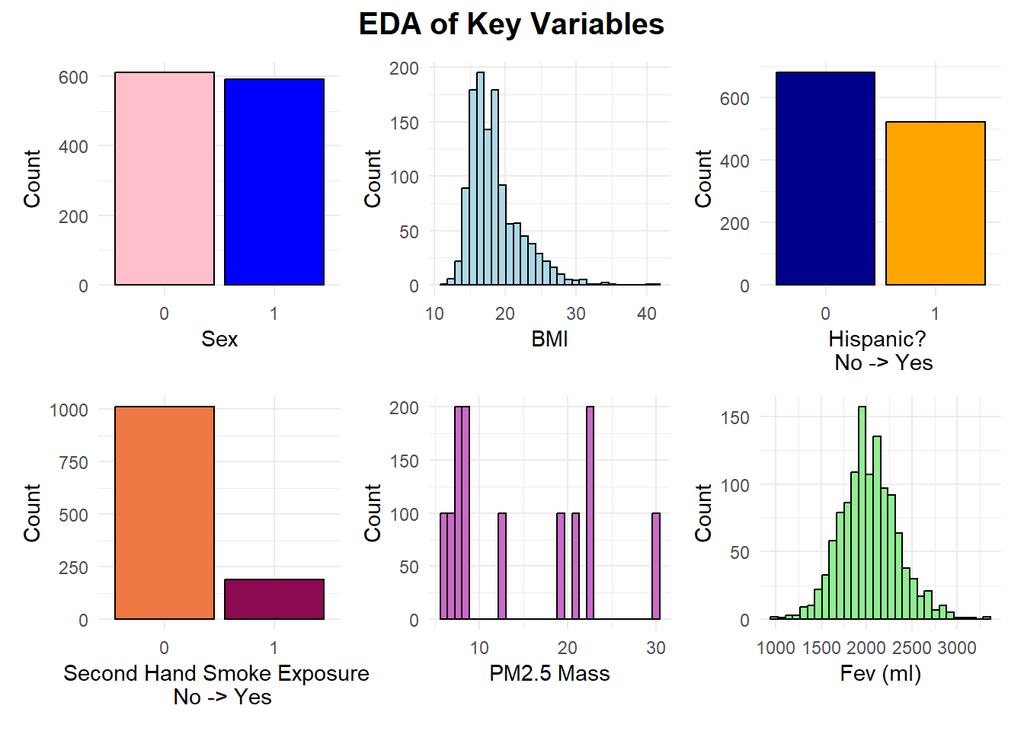

```r
library(cowplot)
#install.packages("patchwork")
library(patchwork)
theme_set(theme_minimal())

plot1 = chs_imputed %>% ggplot(aes(x = as.factor(male), fill = as.factor(male))) +
  geom_bar(color = "black") +
  scale_fill_manual(
    values = c("0" = "pink", "1" = "blue")) +
  labs(x = "Sex", y = "Count") +
  theme(legend.position = "none")


plot2 = chs_imputed %>% ggplot(aes(x = bmi)) +
  geom_histogram(fill = "lightblue", color = "black") +
  labs(x = "BMI", y = "Count")


plot3 = chs_imputed %>%
  ggplot(aes(x = as.factor(hispanic), fill = as.factor(hispanic))) +
  geom_bar(color = "black") +
  scale_fill_manual(values = c("0" = "darkblue", "1" = "orange")) +
  labs(x = "Hispanic? \n No -> Yes", y = "Count") +
  theme(legend.position = "none")


plot4 = chs_imputed %>%
  ggplot(aes(x = pm25_mass)) +
  geom_histogram(fill = "orchid3", color = "black") +
  labs(x = "PM2.5 Mass", y = "Count")

plot5 = chs_imputed %>%
  ggplot(aes(x = smoke, , fill = smoke)) +
  geom_bar(color = "black") +
  scale_fill_manual(values = c("0" = "sienna2", "1" = "deeppink4")) +
  labs(x = "Second Hand Smoke Exposure \n No -> Yes", y = "Count") +
  theme(legend.position = "none")

plot6 = chs_imputed %>%
  ggplot(aes(x = fev)) +
  geom_histogram(fill = "lightgreen", color = "black") +
  labs(x = "Fev (ml)", y = "Count")

combined_plot = (plot1 + plot2 + plot3) /
                 (plot5 + plot4 + plot6) +
  plot_annotation(
    title = "EDA of Key Variables",
    theme = theme(
      plot.title = element_text(size = 15, face = "bold", hjust = 0.5)))

combined_plot
```

```r
m1 = lm(data = chs_imputed, fev ~ smoke_gas_exposure)
summary(m1)
```

```
Call:
lm(formula = fev ~ smoke_gas_exposure, data = chs_imputed)

Residuals:
    Min      1Q  Median      3Q     Max
-1037.8  -205.3   -12.0   190.7  1301.0

Coefficients:
                                             Estimate Std. Error t value
(Intercept)                                  2024.778     25.633  78.991
smoke_gas_exposureGas Stove Exposure           -2.107     28.017  -0.075
smoke_gas_exposureNo Exposure                  31.915     33.453   0.954
smoke_gas_exposureSecond Hand Smoke Exposure   30.936     58.888   0.525
                                             Pr(>|t|)
(Intercept)                                    <2e-16 ***
smoke_gas_exposureGas Stove Exposure            0.940
smoke_gas_exposureNo Exposure                   0.340
smoke_gas_exposureSecond Hand Smoke Exposure    0.599
---
Signif. codes:  0 '***' 0.001 '**' 0.01 '*' 0.05 '.' 0.1 ' ' 1

Residual standard error: 318.1 on 1196 degrees of freedom
Multiple R-squared:  0.001868,  Adjusted R-squared:  -0.0006354
F-statistic: 0.7462 on 3 and 1196 DF,  p-value: 0.5246
```

```r
m2 = lm(data = chs_imputed, fev ~ pm25_mass)
summary(m2)
```

```
Call:
lm(formula = fev ~ pm25_mass, data = chs_imputed)

Residuals:
     Min       1Q   Median       3Q      Max
-1070.63  -206.57   -13.33   195.87  1277.65

Coefficients:
            Estimate Std. Error t value Pr(>|t|)
(Intercept) 2073.452     19.309 107.383   <2e-16 ***
pm25_mass     -3.016      1.184  -2.548    0.011 *
---
Signif. codes:  0 '***' 0.001 '**' 0.01 '*' 0.05 '.' 0.1 ' ' 1

Residual standard error: 317.3 on 1198 degrees of freedom
Multiple R-squared:  0.005389,  Adjusted R-squared:  0.004559
F-statistic: 6.492 on 1 and 1198 DF,  p-value: 0.01096
```

```r
m3 = lm(data = chs_imputed, fev ~ bmi)
summary(m3)
```

```
Call:
lm(formula = fev ~ bmi, data = chs_imputed)

Residuals:
    Min      1Q  Median      3Q     Max
-989.47 -193.88  -11.32  179.43 1305.46

Coefficients:
            Estimate Std. Error t value Pr(>|t|)
(Intercept)  1452.46      44.49   32.65   <2e-16 ***
bmi            31.23       2.36   13.23   <2e-16 ***
---
Signif. codes:  0 '***' 0.001 '**' 0.01 '*' 0.05 '.' 0.1 ' ' 1

Residual standard error: 297.2 on 1198 degrees of freedom
Multiple R-squared:  0.1275,    Adjusted R-squared:  0.1268
F-statistic: 175.1 on 1 and 1198 DF,  p-value: < 2.2e-16
```

Our chs_imputed data table has 1200 rows and 51 columns. Of the columns, the ones I chose to focus on were Sex (Binary), Hispanic (Binary), PM2.5_Mass (Numeric), Smoke_gas_exposure (factor), BMI (both numeric and factor), and FEV (numeric). I also took a brief look at the many PM2.5 readings that were collected in this study. FEV is roughly normally distributed with a mean around 2000, making it a good response variable for linear regression. BMI is slightly skewed right, which is typical. There were roughly the same amount of males and females in the study, but less Hispanics than non Hispanics. About 1/6th of children were exposed to second hand smoke of some kind. Finally, the graph for PM2.5 is rather boring - each town got a reading, but there are only a limited number of towns. Using linear models Y~fev and Y~smoke_gas_exposure we see no correlation (p = 0.5246) between smoke and gas exposure and fev reading, but see a significant negative relationship between pm25_mass and fev (p = 0.01096). Finally we see BMI is highly correlated with fev reading (p = 2.2e-16) and is statistically significant. From these linear models I would initially look further into pm2.5 mass and fev, as well as BMI, as there appears to be a relationship.

## Visualization

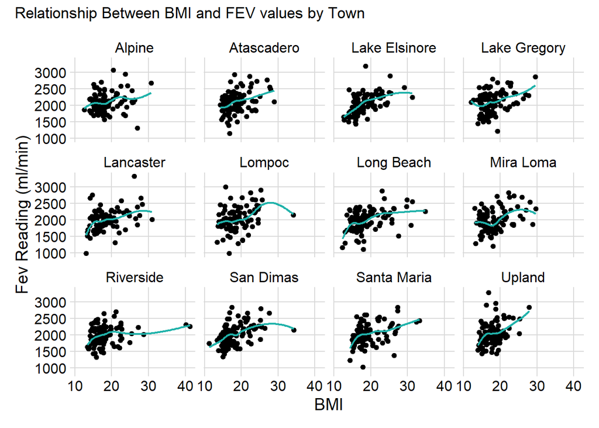

```r
chs_imputed %>% ggplot(aes(x = bmi, y = fev)) +
  geom_point(size = 1.5) +
  facet_wrap(~townname) +
  geom_smooth(se = F, linewidth = 0.8, color = "lightseagreen") +
  labs(x ="BMI", y = "Fev Reading (ml/min)") + plot_annotation(title = "Relationship Between BMI and FEV values by Town") + theme_minimal_grid()
```

There appears to be a positive correlation between BMI and Fev readings across most towns. The higher BMI the children had, the higher Fev reading they tended to have. Some of these regression lines are hindered by outliers in the data. Lompoc for instance would have a very high correlation if not for the subject with a BMI over 30. Overall these graphs support out hypothesis that BMI increases Fev test readings in the children.

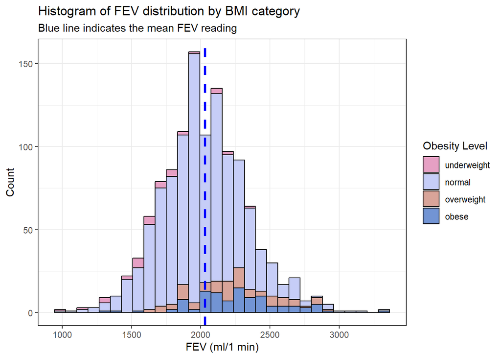

```r
library(wesanderson) #Using fun color palette
ggplot(data = chs_imputed) + geom_histogram(aes(x = fev, fill = obesity_level), color = "black") +
  theme_bw() +
  labs(x = "FEV (ml/1 min)",
       y = "Count",
       title = "Histogram of FEV distribution by BMI category",
       fill = "Obesity Level",
       subtitle = "Blue line indicates the mean FEV reading") +
  scale_fill_manual(values = wes_palette(n = 4, name = "GrandBudapest2")) +
  geom_vline(aes(xintercept = mean(fev, na.rm = TRUE)),
             color = "blue",
             linewidth = 1.2,
             linetype = "dashed")
```

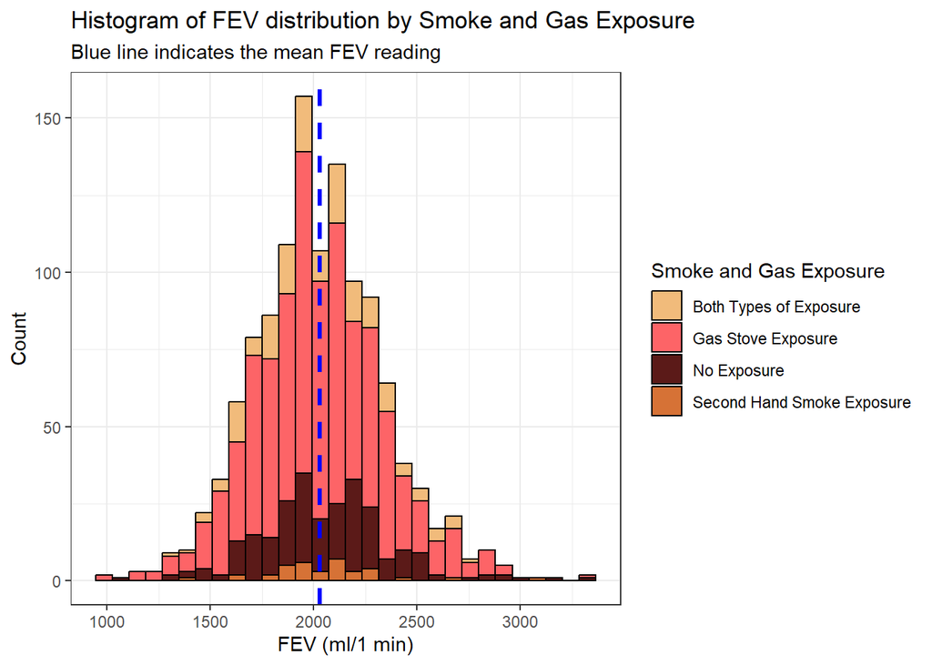

```r
ggplot(data = chs_imputed) + geom_histogram(aes(x = fev, fill = smoke_gas_exposure), color = "black") +
  theme_bw() +
  labs(x = "FEV (ml/1 min)",
       y = "Count",
       title = "Histogram of FEV distribution by Smoke and Gas Exposure",
       fill = "Smoke and Gas Exposure",
       subtitle = "Blue line indicates the mean FEV reading") +
  scale_fill_manual(values = wes_palette(n = 4, name = "GrandBudapest1")) +
  geom_vline(aes(xintercept = mean(fev, na.rm = TRUE)), color = "blue", linewidth = 1.2, linetype = "dashed")
```

What we see in these histograms confirms what we hypothesized and saw in previous exercises. Smoke and gas exposure does not appear to impact FEV readings. There appear to be similar proportions of each group in what we would expect to see in a normal distribution (that is, ~65% of the data for each category falls 1 standard deviation away from the mean and so on). No group is unequally distributed left or right. We do not see the same for BMI and FEV. More of the children in the overweight and obese category have higher FEV readings, their portion of the bar graph is shifted to the right. Conversely we see that those in the underweight category were more concentrated near the left tail of the FEV distribution.

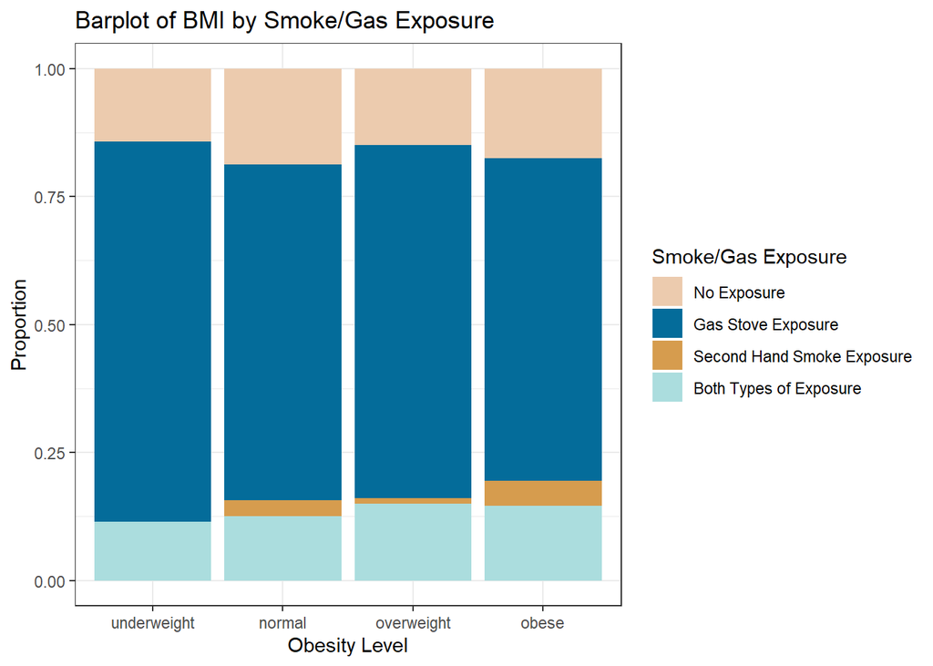

```r
chs_imputed$smoke_gas_exposure = factor(chs_imputed$smoke_gas_exposure, levels = c("No Exposure", "Gas Stove Exposure", "Second Hand Smoke Exposure", "Both Types of Exposure"))

ggplot(data = chs_imputed, aes(x = obesity_level, fill = smoke_gas_exposure)) +
  geom_bar(position = "fill") +
  theme_bw() +
  labs(x = "Obesity Level",
       y = "Proportion",
       title = "Barplot of BMI by Smoke/Gas Exposure",
       fill = "Smoke/Gas Exposure"
       ) +
  scale_fill_manual(values = wes_palette(n = 4, name = "Darjeeling2"))
```

There are a few key takeaways from the bar chart displaying the distribution of obesity level and smoke and gas exposure. More individuals who are classified as obese have been exposed to second hand smoke exposure. We also see a slight uptick in the proportion of individuals who were exposed to both a gas stove and second hand smoke as we go up in obesity level. Finally we see no noticeable trend between no smoke exposure and obesity level as well as just gas exposure.

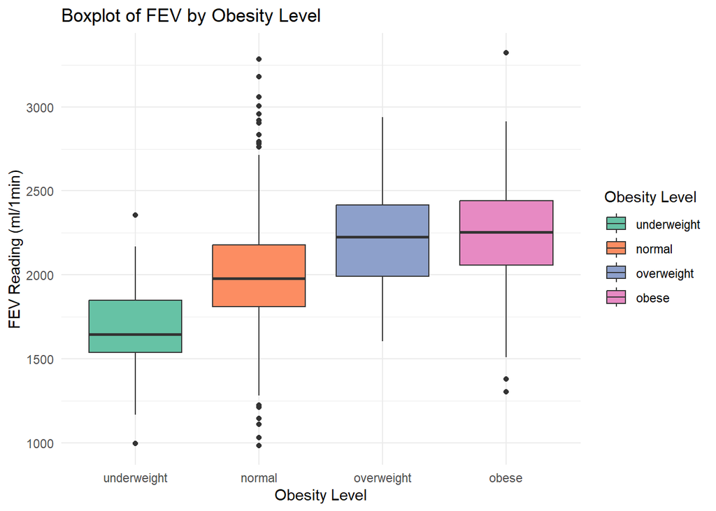

```r
ggplot(chs_imputed, aes(x=obesity_level, y=fev, fill=obesity_level)) +
  geom_boxplot() +
  theme_minimal() +
  scale_fill_brewer(palette="Set2") +
  labs(x = "Obesity Level",
       y = "FEV Reading (ml/1min)",
       title = "Boxplot of FEV by Obesity Level",
       fill = "Obesity Level"
       )
```

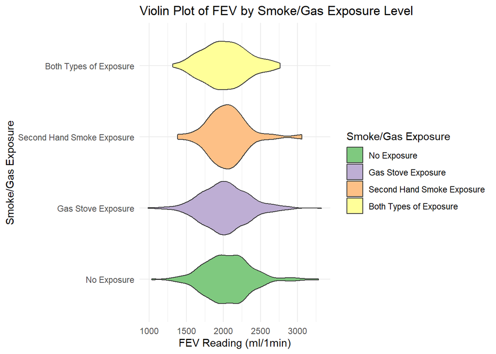

```r
ggplot(chs_imputed, aes(x=smoke_gas_exposure, y=fev, fill=smoke_gas_exposure)) +
  geom_violin() +
  theme_minimal() +
  scale_fill_brewer(palette="Accent") +
  labs(x = "Smoke/Gas Exposure",
       y = "FEV Reading (ml/1min)",
       title = "Violin Plot of FEV by Smoke/Gas Exposure Level",
       fill = "Smoke/Gas Exposure"
       ) +
  coord_flip()
```

```r
library(leaflet)
palette = colorNumeric(
  palette = "viridis",
  domain = chs_imputed$pm25_mass
)

leaflet(data = chs_imputed) %>%
  addTiles() %>%
  addCircleMarkers(
    ~lon, ~lat,
    radius = ~pm25_mass,
    stroke = FALSE,
    fillColor = ~palette(pm25_mass),
    fillOpacity = 0.7,
    label = ~paste0(townname, ": ", pm25_mass, " µg/m^3")
  ) %>%
  addLegend(
    "bottomright",
    values = ~pm25_mass,
    pal = palette,
    title = "PM2.5 (µg/m^3)"
  )
```

[interactive chart not shown]

Exploring the relationship between town and PM2.5 mass spatially, we see that towns closer to Los Angeles and its bigger subsidiaries had a high PM2.5 on average. Mira Loma had the highest PM2.5 reading at 29.97, while Lompoc had the least (5.96)

```r
#install.packages("ggiraph")
library(ggiraph)
gg_point = ggplot(data = chs_imputed, aes(x = pm25_mass, y = fev)) +
    geom_point_interactive(aes(tooltip = paste0(
        "Town: ", townname,
        "<br>PM2.5: ", pm25_mass,
        "<br>FEV: ", fev),
        data_id = townname,
        color = townname)) +
  geom_smooth( color = "black") +
  theme_minimal() +
  labs(x = "PM2.5 Mass",
       y = "FEV Reading (ml/1min)",
       title = "Interactive Scatterplot of PM2.5 mass and FEV",
       color = "Town Name"
       )

girafe(ggobj = gg_point)
```

[interactive chart not shown]

I chose a scatter plot to examine the relationship between PM2.5 mass and FEW reading. We see a slight (emphasis on slight) but noticeable downward trend. That is to say, towns with higher PM2.5 mass values scored lower on FEV readings on average. This trend is consistent across towns, but each town only has 1 PM2.5 mass reading, which makes this scatter plot look somewhat uninteresting.

## Conclusions

We observed a positive significant relationship between BMI and FEV visually and through statistical modeling. We did not observe any relationship between smoke and gas exposure and fev, although we did see some connection between it and BMI which could be interesting to explore further. Finally we saw a significant negative association between PM2.5 mass and FEW output, which was seen visually (rather ingloriously).